# Dissecting tumor transcriptional heterogeneity from multi-tumor single-cell RNA-seq data using generalized binary covariance decomposition

Yusha Liu

2023-08-08

## Overview

This vignette shows how to apply “generalized binary covariance decomposition” (GBCD) to jointly analyze single-cell RNA-seq (scRNA-seq) data from *malignant cells* collected from multiple patients and/or studies, using a head and neck squamous cell carcinoma (HNSCC) dataset from [Puram et al. 2017](https://doi.org/10.1016/j.cell.2017.10.044).

GBCD can effectively dissect tumor transcriptional heterogeneity into patient/study-specific and shared gene expression programs (GEPs). GBCD is “unsupervised” in that, unlike tumor-by-tumor (e.g., [Puram et al. (2017)](https://doi.org/10.1016/j.cell.2017.10.044)) and many harmonization approaches (e.g., [Harmony](https://portals.broadinstitute.org/harmony), [Liger](https://github.com/welch-lab/liger)), it does not use information about which cell comes from which tumor or study. Instead, GBCD only requires the combined scRNA-seq data from all tumors, which are stored as an $N \times J$ matrix $Y$ of expression values with entries $y_{ij}$, where $i=1,\dots,N$ indexes malignant cells and $j=1,\dots,J$ indexes genes. In typical applications, $Y$ contains log-transformed pseudo-count-modified UMI counts (“log-pc counts”).

GBCD ultimately yields a decomposition of the expression data matrix $Y$ into matrices $L$ and $F$ such that $Y \approx L F^T$, or equivalently,
$$y_{ij} \approx \sum_{k=1}^K l_{ik}
f_{jk}.$$
The $K$ components should be interpretable as GEPs, with $l_{ik}$ representing the membership of cell $i$ in GEP $k$, and $f_{jk}$ representing the effect of GEP $k$ on the expression of gene $j$. When $y_{ij}$ are log-pc counts, each $f_{jk}$ approximately represents the log-fold change (LFC) associated with membership in GEP $k$, so we refer to the $f_{jk}$ values as LFCs, and to the vector of LFCs $(f_{1k}, \dots, f_{Jk})^T$ as the “signature” of GEP $k$.

We begin our analysis by loading the R packages used in the analysis, as well as some custom functions implementing the GBCD model fitting and interpretation.. Then we show how to apply GBCD to the HNSCC dataset step-by-step.

```r
library(ggplot2)
library(cowplot)
library(RColorBrewer)
library(ggrepel)
library(pheatmap)
library(gridExtra)
library(Seurat)
library(Matrix)
library(ebnm)
library(flashier)
library(magrittr)
library(ashr)
source("../code/fit_cov_ebnmf.R")
```

## The HNSCC dataset

This data set contains gene expression data for n = 2,176 malignant cells collected in primary tumors from 10 HNSCC patients, as well as matching lymph node (LN) metastases from 5 of these patients. [Puram et al. (2017)](https://doi.org/10.1016/j.cell.2017.10.044) found that each of these 10 patients mapped to a molecular subtype of HNSCC, whose signatures were previously defined by analysis of bulk expression data of 279 [TCGA](https://doi.org/10.1038%2Fnature14129) HNSCC tumors.

Unlike more recently generated data sets, the HNSCC data are not UMI counts; rather, they are read counts produced by SMART-Seq2. Following [Puram et al. (2017)](https://doi.org/10.1016/j.cell.2017.10.044), we define the transformed counts as $y_{ij} = \log_2(1 + \mathrm{TPM}_{ij}/10)$, where $\mathrm{TPM}_{ij}$ is the transcript-per-million (TPM) value for gene $j$ in cell $i$.

```r
load("hnscc.RData")
dim(Y)
print(head(info),row.names = FALSE)
# [1]  2176 17113
#                    cell.id lymph.node cancer.cell cell.type sample.id   subject
#     HN26_P14_D11_S239_comb          1           1         0       T26 MEEI26_LN
#     HN26_P25_H09_S189_comb          1           1         0       T26 MEEI26_LN
#     HN26_P14_H06_S282_comb          1           1         0       T26 MEEI26_LN
#     HN25_P25_C04_S316_comb          1           1         0       T25 MEEI25_LN
#     HN26_P25_C09_S129_comb          1           1         0       T26 MEEI26_LN
#  HNSCC26_P24_H05_S377_comb          1           1         0       T26 MEEI26_LN
#   subtype
#  Atypical
#  Atypical
#  Atypical
#     Basal
#  Atypical
#  Atypical
```

## Visualize HNSCC data using *t*-SNE

We plot the 2-D *t*-SNE embedding of these $2,176$ malignant cells, which are colored by patient of origin and tumor stage (primary tumor, LN metastasis), and shaped by tumor molecular subtype. We set seed to make the *t*-SNE reproducible.

```r
set.seed(100)
hnscc <- CreateSeuratObject(counts = t(Y), project = "HNSCC", meta.data = info)
# Warning: Feature names cannot have underscores ('_'), replacing with dashes
# ('-')
hnscc <- FindVariableFeatures(hnscc, selection.method = "vst",
                              nfeatures = 5000)
all.genes <- rownames(hnscc)
hnscc <- ScaleData(hnscc, features = all.genes)
# Centering and scaling data matrix
hnscc <- RunPCA(hnscc, features = VariableFeatures(object = hnscc),
                npcs = 50, verbose = FALSE)
hnscc <- RunTSNE(hnscc, dims = 1:50)
```

Due to the presence of strong inter-tumor heterogeneity, these cells demonstrate strong patient effects that are typical of cancer data; the major structure in the *t*-SNE visualization is the clustering of the cells by patient.

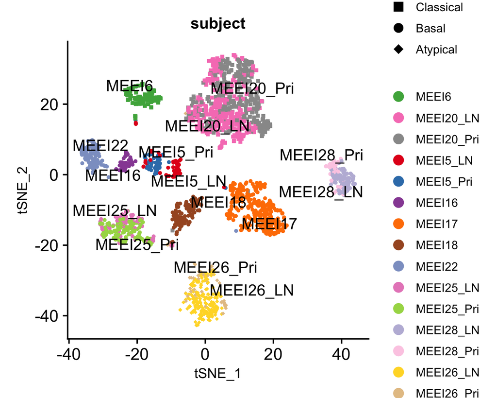

```r
DimPlot(hnscc, label = TRUE, repel = TRUE, pt.size = 1, reduction = "tsne",
        group.by = "subject", shape.by = "subtype", cols = subject_col) +
  guides(shape = guide_legend(override.aes = list(size = 3)), ncol = 1) +
  theme(text = element_text(size = 10)) +
  scale_shape_manual(values = c(15,16,18))
```

## Apply GBCD to estimate GEP memberships and signatures

To fit GBCD, you need to specify `Kmax`, an upper bound of the number of components $K$, for initialization; the number of GEPs returned by GBCD is close to but often not equal to (and can be larger than) `Kmax`. Generally speaking, a larger `Kmax` allows for identifying finer structure in tumor transcriptional heterogeneity at the expense of higher computational cost. A good choice of `Kmax` depends on the complexity of the analyzed data (e.g., the number of patients and studies contained), and is often unknown in advance. You1 are encouraged to explore and compare the results for different values of `Kmax`. After some initial exploration, we set `Kmax` to 24.

You also need to specify a prior for GEP membership values. GBCD assigns a “generalized binary” (GB) prior independently to each entry of $L$,
$$l_{ik}\sim (1-\pi_k^l) \delta_0 + \pi_k^l \:
N_{+} (\mu_k,
\sigma_k^2),$$
where the ratio $\sigma_k/\mu_k$ is fixed at some pre-specified small value. In this analysis, we set $\sigma_k/\mu_k = 0.04$ for all $k$.

```r
fit.gbcd <-
  flash_fit_cov_ebnmf(Y = Y, Kmax = 24,
                      prior = flash_ebnm(prior_family = "generalized_binary",
                                         scale = 0.04),
                      extrapolate = FALSE)
```

Note that you can choose other nonnegative priors for GEP membership values so long as they are defined in the [ebnm](https://stephenslab.github.io/ebnm/) package. For example, you can chose a point-exponential prior by setting `prior = ebnm::ebnm_point_exponential`.

The time to fit GBCD depends on the choice of `Kmax` and the size of the data set being analyzed. It took us a few hours to fit the GBCD model with `Kmax = 24` to the HNSCC data set.

Since it takes a while to fit GBCD to the HNSCC dataset, we directly load in the saved output from the above call and show how to interpret the results.

```r
load("hnscc_gbcd.RData")
```

The `flash_fit_cov_ebnmf` output contains the membership estimates, stored as an $n \times K$ matrix,

```r
dim(fit.gbcd$L)
fit.gbcd$L[1:4,1:5]
# [1] 2176   29
#                         Baseline          GEP1          GEP2          GEP3
# HN26_P14_D11_S239_comb 0.7404634 3.538229e-110 2.323954e-141  9.039494e-01
# HN26_P25_H09_S189_comb 0.6666176 5.623800e-137 9.582078e-135  7.786085e-01
# HN26_P14_H06_S282_comb 0.7976365 8.636394e-136  2.833297e-01  7.258564e-01
# HN25_P25_C04_S316_comb 0.4193556 6.158516e-137  5.124139e-01 4.286821e-135
#                                 GEP4
# HN26_P14_D11_S239_comb 4.589753e-141
# HN26_P25_H09_S189_comb 9.840882e-136
# HN26_P14_H06_S282_comb 2.828108e-122
# HN25_P25_C04_S316_comb 1.527244e-135
```

and posterior statistics for the LFC estimates, including the posterior means, stored as an $m \times K$ matrix,

```r
dim(fit.gbcd$F$lfc)
fit.gbcd$F$lfc[1:4,1:5]
# [1] 17113    29
#              Baseline          GEP1         GEP2          GEP3          GEP4
# C9orf152 0.0001609319  0.0002929911  0.000234652 -0.0004093085  0.0002814196
# ELMO2    2.0116827172 -0.0060056851 -0.601995065  0.0387999604 -0.0188075633
# PNMA1    1.6386413103 -0.0021806303 -1.244428917  0.0164347046 -0.0059650037
# MMP2     0.4807052706 -0.3115376229  1.673189435 -0.4256140576 -1.1229331251
```

## GEP membership estimates

We now examine at the entries of the `L` matrix giving membership estimates of cell $i$ in GEP $k$. Here we visually compare the memberships to the patient labels and provided tumor subtype annotations with a heatmap.

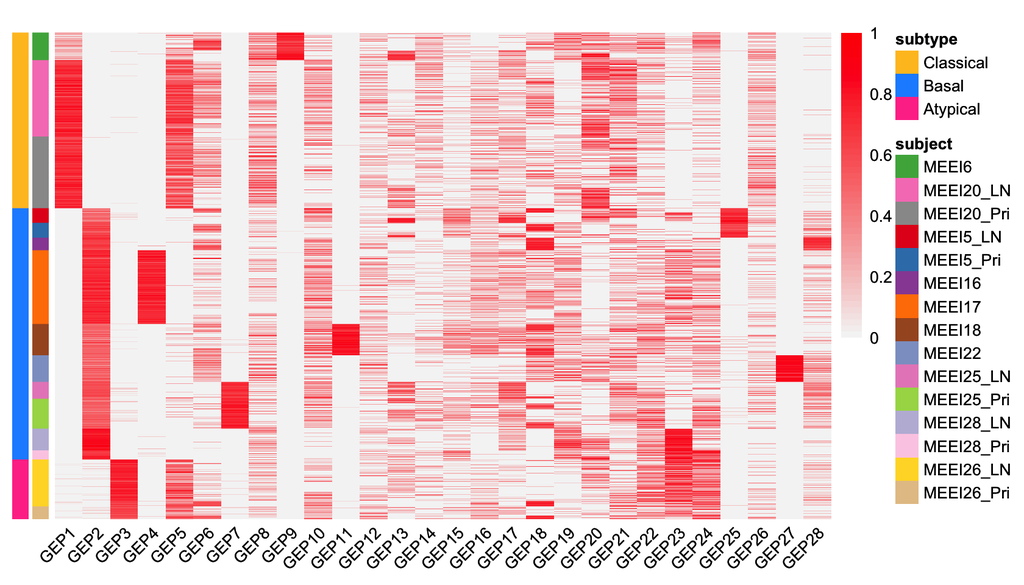

```r
anno <- data.frame(subject = info$subject,
                   subtype = info$subtype)
rownames(anno) <- rownames(fit.gbcd$L)
anno_colors <- list(subject = subject_col,
                    subtype = subtype_col)
cols <- colorRampPalette(c("gray96","red"))(50)
brks <- seq(0,1,0.02)
rows <- order(anno$subject)
p <- pheatmap(fit.gbcd$L[rows, -1], cluster_rows = FALSE, cluster_cols = FALSE,
         show_rownames = FALSE, annotation_row = anno,
         annotation_colors = anno_colors, annotation_names_row = FALSE,
         angle_col = 45, fontsize = 8, color = cols, breaks = brks,
         main = "")
print(p)
```

This heatmap shows the membership values of the n = 2,176 cells (the rows in the heatmap) and the 28 GEPs (the columns in the heatmap). (The membership values for the “baseline” GEP are not shown.) Cells are arranged top-to-bottom by tumor molecular subtype and patient of origin. We rescaled the membership values separately for each GEP so that the maximum membership for each GEP is always 1.

From this heatmap, we see that GEPs 1, 2 and 3 correspond closely to the molecular subtypes previously defined based on bulk RNA-seq data: GEP1 is largely active only in cells from the 2 classical patients, GEP2 is mainly active in cells from the 7 basal patients, and GEP3 is mainly active in cells from the 1 atypical patient. This demonstrates that GBCD can reconstruct the molecular subtype information from the single cell data alone.

Among other GEPs, some are active predominantly in an individual patient and can thus be interpreted as patient-specific GEPs. We interpret GEPs 4, 7, 9, 11, 25, 27 as “patient-specific GEPs”; the remaining GEPs are shared across multiple patients but are capturing something different than these previously defined molecular subtypes.

## GEP signature estimates

The GEP signature estimates $f_{jk}$ represent approximately the log-fold change (using t he base-2 logarithm) associated with membership in GEP $k$. We take the approach commonly used in differential expression analysis and create a “volcano plot” to visualize the gene signature for a GEP. As an example, this is the volcano plot for GEP2:

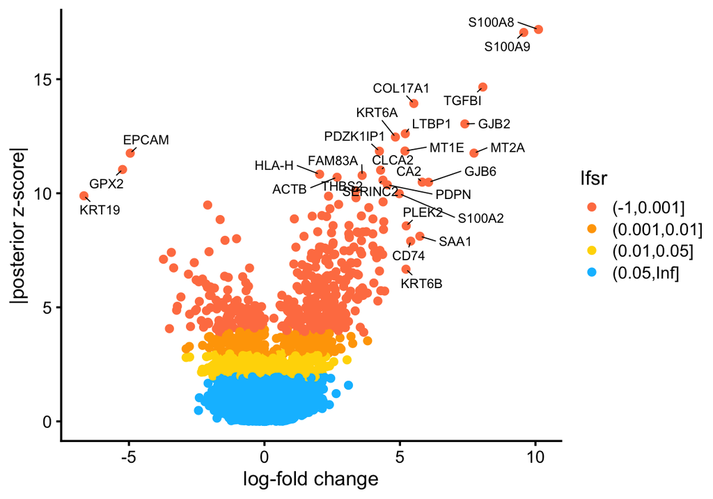

```r
k <- "GEP2"
pdat <- data.frame(gene = rownames(fit.gbcd$F$lfc),
                   lfc  = fit.gbcd$F$lfc[,k],
                   z    = abs(fit.gbcd$F$z_score[,k]),
                   lfsr = fit.gbcd$F$lfsr[,k],
                   stringsAsFactors = FALSE)
pdat <- transform(pdat,lfsr = cut(lfsr, c(-1,0.001,0.01,0.05,Inf)))
rows  <- with(pdat, which(!(abs(lfc) > quantile(abs(lfc),0.999) | (z > 10))))
pdat[rows, "gene"] <- ""
ggplot(pdat, aes(x = lfc, y = z, color = lfsr, label = gene)) +
  geom_point() +
  geom_text_repel(color = "black", size = 2.3, segment.color = "black",
                  segment.size = 0.25, min.segment.length = 0,
                  max.overlaps = Inf, na.rm = TRUE) +
  scale_color_manual(values = c("coral","orange","gold","deepskyblue")) +
  labs(x = "log-fold change", y = "|posterior z-score|") +
  theme_cowplot(font_size = 10)
```

The significance measure here is not a *p*-value, but rather a [local false sign rate (lfsr)](https://doi.org/10.1093/biostatistics/kxw041).

## Session info

This is the version of R and the packages that were used to generate these results.

```r
sessionInfo()
# R version 4.2.1 (2022-06-23)
# Platform: aarch64-apple-darwin20 (64-bit)
# Running under: macOS Monterey 12.4
#
# Matrix products: default
# BLAS:   /Library/Frameworks/R.framework/Versions/4.2-arm64/Resources/lib/libRblas.0.dylib
# LAPACK: /Library/Frameworks/R.framework/Versions/4.2-arm64/Resources/lib/libRlapack.dylib
#
# locale:
# [1] en_US.UTF-8/en_US.UTF-8/en_US.UTF-8/C/en_US.UTF-8/en_US.UTF-8
#
# attached base packages:
# [1] stats     graphics  grDevices utils     datasets  methods   base
#
# other attached packages:
#  [1] ashr_2.2-54        flashier_0.2.51    magrittr_2.0.3     ebnm_1.0-46
#  [5] Matrix_1.4-1       sp_1.5-0           SeuratObject_4.1.0 Seurat_4.1.1
#  [9] gridExtra_2.3      pheatmap_1.0.12    ggrepel_0.9.1      RColorBrewer_1.1-3
# [13] cowplot_1.1.1      ggplot2_3.4.2
#
# loaded via a namespace (and not attached):
#   [1] Rtsne_0.16            colorspace_2.0-3      deldir_1.0-6
#   [4] ellipsis_0.3.2        ggridges_0.5.3        rstudioapi_0.14
#   [7] spatstat.data_2.2-0   farver_2.1.1          leiden_0.4.2
#  [10] listenv_0.8.0         fansi_1.0.3           codetools_0.2-18
#  [13] splines_4.2.1         cachem_1.0.6          knitr_1.39
#  [16] polyclip_1.10-0       jsonlite_1.8.7        ica_1.0-3
#  [19] cluster_2.1.3         png_0.1-7             rgeos_0.5-9
#  [22] uwot_0.1.11           shiny_1.7.2           sctransform_0.3.3
#  [25] spatstat.sparse_2.1-1 compiler_4.2.1        httr_1.4.6
#  [28] fastmap_1.1.0         lazyeval_0.2.2        cli_3.6.1
#  [31] later_1.3.0           htmltools_0.5.3       tools_4.2.1
#  [34] igraph_1.3.4          gtable_0.3.0          glue_1.6.2
#  [37] RANN_2.6.1            reshape2_1.4.4        dplyr_1.1.2
#  [40] Rcpp_1.0.9            softImpute_1.4-1      scattermore_0.8
#  [43] jquerylib_0.1.4       vctrs_0.6.3           nlme_3.1-157
#  [46] progressr_0.10.1      lmtest_0.9-40         spatstat.random_2.2-0
#  [49] xfun_0.31             stringr_1.5.0         globals_0.15.1
#  [52] trust_0.1-8           mime_0.12             miniUI_0.1.1.1
#  [55] lifecycle_1.0.3       irlba_2.3.5           goftest_1.2-3
#  [58] future_1.27.0         MASS_7.3-57           zoo_1.8-10
#  [61] scales_1.2.0          spatstat.core_2.4-4   promises_1.2.0.1
#  [64] spatstat.utils_2.3-1  parallel_4.2.1        yaml_2.3.5
#  [67] reticulate_1.25       pbapply_1.5-0         sass_0.4.2
#  [70] rpart_4.1.16          SQUAREM_2021.1        stringi_1.7.8
#  [73] highr_0.9             deconvolveR_1.2-1     horseshoe_0.2.0
#  [76] truncnorm_1.0-8       rlang_1.1.1           pkgconfig_2.0.3
#  [79] matrixStats_0.62.0    invgamma_1.1          evaluate_0.15
#  [82] lattice_0.20-45       ROCR_1.0-11           purrr_1.0.1
#  [85] tensor_1.5            labeling_0.4.2        patchwork_1.1.2
#  [88] htmlwidgets_1.5.4     tidyselect_1.2.0      parallelly_1.32.1
#  [91] RcppAnnoy_0.0.19      plyr_1.8.7            R6_2.5.1
#  [94] generics_0.1.3        DBI_1.1.3             mgcv_1.8-40
#  [97] pillar_1.9.0          withr_2.5.0           fitdistrplus_1.1-8
# [100] mixsqp_0.3-43         survival_3.5-5        abind_1.4-5
# [103] tibble_3.2.1          future.apply_1.9.0    KernSmooth_2.23-20
# [106] utf8_1.2.2            spatstat.geom_2.4-0   plotly_4.10.0
# [109] rmarkdown_2.14        grid_4.2.1            data.table_1.14.2
# [112] digest_0.6.29         xtable_1.8-4          tidyr_1.3.0
# [115] httpuv_1.6.5          munsell_0.5.0         viridisLite_0.4.0
# [118] bslib_0.4.0
```